# Analitica ecpl_volume

### Conclusiones del Análisis ecpl_volume

El feature ecpl_volume tiene diferentes trabajos de limpieza para lograr un estimador de posición y establecer su distribución.

Estos pasos siguientes fueron realizados a partir de exploración gráfica de los datos y bajo conocimiento de su captura y procesamiento.

**Paso 1**: separar valores en control y estudio.  
**Paso 2:** verificar valores repetidos. Esto sucede al rellenar valores nulos en su versión original y como criterio de inicio, tuvimos que tomar un punto medio.  
**Paso 3:** Limpiar los outliers en esta ocasión en datos de control. Esta vez se ha realizado de esta forma, ya que al juntar control y estudio, vemos que se pierde las diferencias los datos de estudio. Esto genera mayor dispersión al finalizar.

Luego, verificando y ajustando a distribuciones teóricas, se asemeja a la distribución normal. Realizamos los ajustes, aunque sus datos no logran ajustar del todo.  
También, realizamos pruebas con distribución libre o sin Ajuste total a una distribución teórica, utilizamos diferentes nucleos y ancho de banda.

Los selectores de ancho de banda como: **Silverman** o **Scott son eficientes y rápidos con distribución normal**. También es viable utilizar la versión que más ajustada cuando tenemos dudas de distribución: **método Sheather y Jones**.

Básicamente, estamos indicando que los estimadores seguirán el nucleo y ancho de banda utilizado, aportando mayor flexibilidad, aunque perdiendo eficiencia.

La decisión está en sus estimadores y ajuste de distribución. Cuando ajustamos a una distribución teórica de la normal (es asintóticamente normal y de consistencia fuerte, es decir tanto la media y sd son insesgado) , observamos que sus estimadores de muestra limpia sin duplicados son iguales a la **media = 6859.254 y sd = 3227.612**, con error Std mayor que la obtenida en datos puros de la base, sin embargo estos datos de base tienen duplicados por ajustes y no por composición natural, e invalida cualquier conclusión comparado relacionado al error estandar entre estos estimadores. Observando de manera general, no logra ajustar correctamente la muestra a distribución normal.

Ahora bien, utilizando la muestra limpia de duplicados y outliers, al tomar una distribución libre (de comportamiento asintótico debilmente consistentes, su media es insesgado y sd posee sesgo), media y mediana se igualan **= 6889**, y no posee restricciones de supuestos; aunque sus cuartiles varían en base al método seleccionado. Nuevamente recordar que si nuestra distribución se acerca a una normal, el método Silverman, es sólido, donde **1Q=1804 y 3Q=11974**. También es importante destacar los estimadores utilizados en Silverman y Scott poseen propiedades en este método que permiten utilizar LGN y TCL. Por otro lado podemos comparar con el método más libre **Sheather y Jones *1Q=1872 y 3Q=11906, si bien este modelo no posee todas las propiedades de Silverman y Scott.***

> **Podemos concluir, que la versión de Silverman se ajusta apropiadamente a la distribución de estos datos del feature ecpl_volume**

#### Con Ajuste a una distribución teórica

Normal ajustado sin duplicados  
estimate Std. Error mean **6859.254** 376.6596 sd **3227.612** 266.8772  
Normal sin ajustes  
estimate Std. Error mean **6884.02** 317.9694 sd **3119.48** 224.8383

Call: density.default(x = dataendcleanun, kernel = “gaussian”)  
Data: dataendcleanun (73 obs.); Bandwidth ‘bw’ = 1199  
**Utilizo: Metodo Silverman**

```r
### Ubicacion de datos
setwd("C:/hcgalvan/Repositorios/hcgalvan_project/data/union/End")
temp = gsub(".*target.*", "", readLines("seleccionestudio.csv"))
data<-read.table(text=temp, sep=",", header=TRUE)
ecplvl <-data$ecpl_volume
### ante valores duplicados, entendiendo que fueron resueltos por valores vacíos, buscamos establecer valores únicos reportados por la base.
dataclean <-unique(data$ecpl_volume)
```

```r
### Ubicacion de datos
setwd("C:/hcgalvan/Repositorios/hcgalvan_project/data/union/End")
temp = gsub(".*target.*", "", readLines("seleccionestudio.csv"))
data<-read.table(text=temp, sep=",", header=TRUE)
ecplvl <-data$ecpl_volume
### ante valores duplicados, entendiendo que fueron resueltos por valores vacíos, buscamos establecer valores únicos reportados por la base.
dataclean <-unique(data$ecpl_volume)
```

#### Tratamiento Ajustado a Distribución y comparativa con/sin outliers

Separamos los datos de la variable de estudio

```r
Control<-(as.numeric(unlist(subset(data, label==1, select=c(ecpl_volume)))))
Estudio<-(as.numeric(unlist(subset(data, label==0, select=c(ecpl_volume)))))
Controlclean<-unique(Control)
Estudioclean<-unique(Estudio)
```

```r
Control<-(as.numeric(unlist(subset(data, label==1, select=c(ecpl_volume)))))
Estudio<-(as.numeric(unlist(subset(data, label==0, select=c(ecpl_volume)))))
Controlclean<-unique(Control)
Estudioclean<-unique(Estudio)
```

```
summary statistics
------
min:  315.327   max:  13463.1
median:  7127.16
mean:  6859.254
estimated sd:  3249.948
estimated skewness:  -0.2700933
estimated kurtosis:  2.359759
```

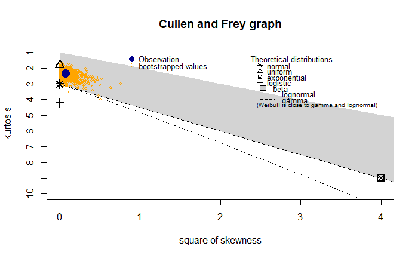

```r
descdist(dataendcleanun, boot = 1000)
```

```
summary statistics
------
min:  315.327   max:  14015.4
median:  6884.02
mean:  6884.02
estimated sd:  3135.856
estimated skewness:  -0.1642622
estimated kurtosis:  2.93517
```

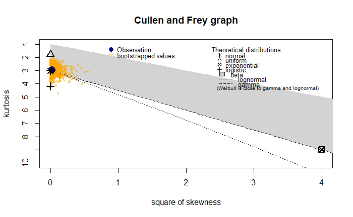

```r
descdist(ecplvl, boot = 1000)
```

Graficamos las distribuciones obtenidos.

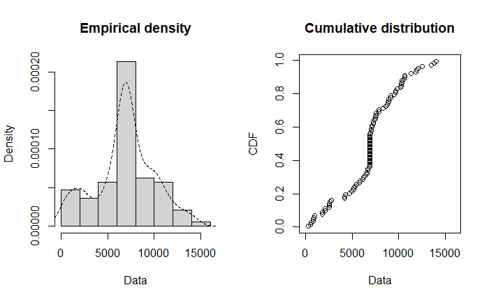

Realizamos descripcion de los valores descriptivos: Ajuste total, parcial y sin ajuste

```r
summary(ecplvl)
```

```
   Min. 1st Qu.  Median    Mean 3rd Qu.    Max.
  315.3  5450.9  6884.0  6884.0  8867.3 14015.4
```

Graficamos la densidad de distribución: Ajuste Total, Parcial y sin ajustes

```r
descdist(dataendcleanun, boot = 1000)
descdist(data$ecpl_volume, boot = 1000)
```

Ajustamos los datos a la distribución Normal

```r
library(glogis)
total<-fitdist(dataendclean, "norm")
total2<-fitdist(dataendcleanun,"norm")
sinajuste<-fitdist(data$ecpl_volume, "norm")
summary(total)
```

```
Fitting of the distribution ' norm ' by maximum likelihood
Parameters :
```

|  | estimate | Std. Error |
| --- | --- | --- |
| mean | 6859.588 | 372.1843 |
| sd | 3205.730 | 263.1740 |

```
Loglikelihood:  -702.3809   AIC:  1408.762   BIC:  1413.37
Correlation matrix:
     mean sd
mean    1  0
sd      0  1
```

```r
summary(total2)
```

```
Fitting of the distribution ' norm ' by maximum likelihood
Parameters :
```

|  | estimate | Std. Error |
| --- | --- | --- |
| mean | 6859.254 | 376.6596 |
| sd | 3227.612 | 266.8772 |

```
Loglikelihood:  -693.3858   AIC:  1390.772   BIC:  1395.353
Correlation matrix:
     mean sd
mean    1  0
sd      0  1
```

```r
summary(sinajuste)
```

```
Fitting of the distribution ' norm ' by maximum likelihood
Parameters :
```

|  | estimate | Std. Error |
| --- | --- | --- |
| mean | 6884.02 | 317.9694 |
| sd | 3119.48 | 224.8383 |

```
Loglikelihood:  -908.5786   AIC:  1821.157   BIC:  1826.286
Correlation matrix:
     mean sd
mean    1  0
sd      0  1
```

```r
par(mfrow = c(2, 2), mar = c(4, 4, 2, 1))
fb <- fitdist(dataendcleanun, "norm")
plot.legend <- c("norm")
denscomp(list(fb), legendtext = plot.legend)
qqcomp(list(fb), legendtext = plot.legend)
cdfcomp(list(fb), legendtext = plot.legend)
ppcomp(list(fb), legendtext = plot.legend)
```

[output not shown]

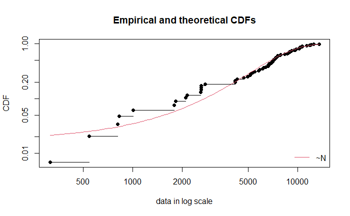

```r
library(actuar)

ATV2 <- dataendcleanun
datos2.l<-fitdist(ATV2, "norm")
cdfcomp(list(datos2.l), xlogscale = TRUE,
        ylogscale = TRUE, legendtext = c("~N"))
```

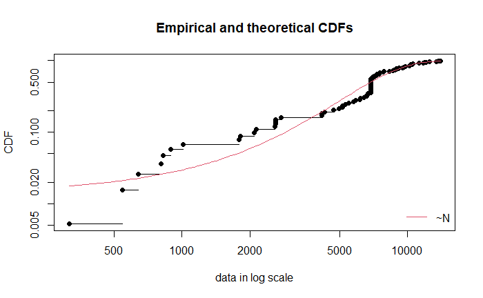

```r
ATV <- data$ecpl_volume
datos.l<-fitdist(ATV, "norm")
cdfcomp(list(datos.l), xlogscale = TRUE,
        ylogscale = TRUE, legendtext = c("~N"))
```

```r
quantile(datos.l, probs = 0.05) # Sin Ajustes de outliers ~Weibull
```

```
Estimated quantiles for each specified probability (non-censored data)
```

|  | p=0.05 |
| --- | --- |
| estimate | 1752.931 |

```r
quantile(datos2.l, probs = 0.05) # Sin outliers ~Weibull
```

```
Estimated quantiles for each specified probability (non-censored data)
```

|  | p=0.05 |
| --- | --- |
| estimate | 1550.305 |

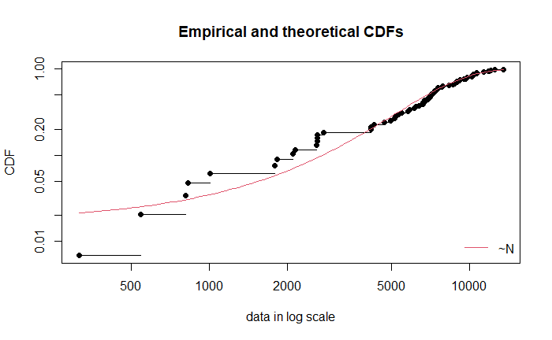

```r
library(actuar)

ATV2 <- dataendcleanun
datos2.l<-fitdist(ATV2, "norm")
cdfcomp(list(datos2.l), xlogscale = TRUE,
        ylogscale = TRUE, legendtext = c("~N"))
```

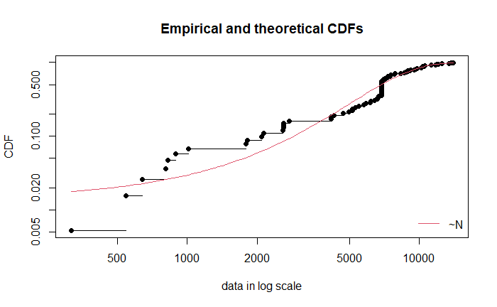

```r
ATV <- data$ecpl_volume
datos.l<-fitdist(ATV, "norm")
cdfcomp(list(datos.l), xlogscale = TRUE,
        ylogscale = TRUE, legendtext = c("~N"))
```

### Analítica NO PARAMÉTRICA; libre distribución

```r
bw.nrd0(dataendcleanun) #regla general de Silverman
```

```
[1] 1198.516
```

```r
bw.nrd(dataendcleanun)  #regla general de Scott
```

```
[1] 1411.585
```

```r
bw.bcv(dataendcleanun)  #convalidación cruzada
```

```
[1] 1568.685
```

```r
bw.ucv(dataendcleanun)  #validación cruzada imparcial
```

```
[1] 516.0063
```

```r
bw.SJ(dataendcleanun)   #Sheather & método Jones
```

```
[1] 1153.445
```

```r
density.default(x = dataendcleanun, kernel = "gaussian")
```

```
Call:
    density.default(x = dataendcleanun, kernel = "gaussian")

Data: dataendcleanun (73 obs.); Bandwidth 'bw' = 1199

       x               y
 Min.   :-3280   Min.   :5.647e-08
 1st Qu.: 1804   1st Qu.:8.561e-06
 Median : 6889   Median :5.074e-05
 Mean   : 6889   Mean   :4.912e-05
 3rd Qu.:11974   3rd Qu.:8.195e-05
 Max.   :17059   Max.   :1.221e-04
```

```r
density.default(x = dataendcleanun, kernel = "epanechnikov")
```

```
Call:
    density.default(x = dataendcleanun, kernel = "epanechnikov")

Data: dataendcleanun (73 obs.); Bandwidth 'bw' = 1199

       x               y
 Min.   :-3280   Min.   :0.000e+00
 1st Qu.: 1804   1st Qu.:9.925e-06
 Median : 6889   Median :4.903e-05
 Mean   : 6889   Mean   :4.912e-05
 3rd Qu.:11974   3rd Qu.:8.044e-05
 Max.   :17059   Max.   :1.175e-04
```

```r
density.default(x = dataendcleanun, bw="nrd", kernel = "gaussian")
```

```
Call:
    density.default(x = dataendcleanun, bw = "nrd", kernel = "gaussian")

Data: dataendcleanun (73 obs.); Bandwidth 'bw' = 1412

       x               y
 Min.   :-3919   Min.   :5.145e-08
 1st Qu.: 1485   1st Qu.:6.386e-06
 Median : 6889   Median :4.441e-05
 Mean   : 6889   Mean   :4.621e-05
 3rd Qu.:12294   3rd Qu.:7.812e-05
 Max.   :17698   Max.   :1.164e-04
```

```r
density.default(x = dataendcleanun, bw="SJ", kernel = "gaussian")
```

```
Call:
    density.default(x = dataendcleanun, bw = "SJ", kernel = "gaussian")

Data: dataendcleanun (73 obs.); Bandwidth 'bw' = 1153

       x               y
 Min.   :-3145   Min.   :5.800e-08
 1st Qu.: 1872   1st Qu.:9.230e-06
 Median : 6889   Median :5.213e-05
 Mean   : 6889   Mean   :4.978e-05
 3rd Qu.:11906   3rd Qu.:8.319e-05
 Max.   :16923   Max.   :1.235e-04
```

```r
density.default(x = dataendcleanun, bw="bcv", kernel = "gaussian")
```

```
Call:
    density.default(x = dataendcleanun, bw = "bcv", kernel = "gaussian")

Data: dataendcleanun (73 obs.); Bandwidth 'bw' = 1569

       x               y
 Min.   :-4391   Min.   :4.909e-08
 1st Qu.: 1249   1st Qu.:5.342e-06
 Median : 6889   Median :4.007e-05
 Mean   : 6889   Mean   :4.428e-05
 3rd Qu.:12529   3rd Qu.:7.602e-05
 Max.   :18169   Max.   :1.129e-04
```

```r
gauss<-function(u)
{
  k<-exp(-(u^2)/2)/sqrt(2*pi)
  return(k)
}

uniforme<-function(u)
{
  ifelse(u>-1 & u<1,1,0)/2  # es mi indicadora y mi calcula el nucleo uniforme
}

f_sombrero<-function(x,k,datos,h) #datos= Xi
{
  s<-0
  for(i in 1:length(datos))
  {
    c<-k((x-datos[i])/h)
    s<-s+c
  }
  f<-s/(length(datos)*h)
  return(f)
}

densidad.est.parzen<-function(x,h,z) # x: datos, z:valor donde exaluo la f
{
  f_sombrero(z,gauss,x,h)
}

nmax<-max(dataendcleanun)
nmin<-min(dataendcleanun)
largo<-length(dataendcleanun)
nuevos<-seq(nmin,nmax,length=largo) #los numeros, son los mínimos y maximos de la muestra

h<-1153

f_estimada1<-densidad.est.parzen(dataendcleanun,h,nuevos)
f_est<-data.frame("x"=nuevos,  "estimada1"=f_estimada1)
f_est2<-data.frame("x"=nuevos, "real"= dataendcleanun, "estimada1"=f_estimada1)
summary(f_est)

ggplot(f_est)+
  geom_line(aes(x=x,y=estimada1),col="steelblue")+
  theme_light()
```

```r
gauss<-function(u)
{
  k<-exp(-(u^2)/2)/sqrt(2*pi)
  return(k)
}

uniforme<-function(u)
{
  ifelse(u>-1 & u<1,1,0)/2  # es mi indicadora y mi calcula el nucleo uniforme
}

f_sombrero<-function(x,k,datos,h) #datos= Xi
{
  s<-0
  for(i in 1:length(datos))
  {
    c<-k((x-datos[i])/h)
    s<-s+c
  }
  f<-s/(length(datos)*h)
  return(f)
}

densidad.est.parzen<-function(x,h,z) # x: datos, z:valor donde exaluo la f
{
  f_sombrero(z,gauss,x,h)
}

nmax<-max(dataendcleanun)
nmin<-min(dataendcleanun)
largo<-length(dataendcleanun)
nuevos<-seq(nmin,nmax,length=largo) #los numeros, son los mínimos y maximos de la muestra

h<-1153

f_estimada1<-densidad.est.parzen(dataendcleanun,h,nuevos)
f_est<-data.frame("x"=nuevos,  "estimada1"=f_estimada1)
f_est2<-data.frame("x"=nuevos, "real"= dataendcleanun, "estimada1"=f_estimada1)
summary(f_est)
```

```
       x             estimada1
 Min.   :  315.3   Min.   :1.620e-05
 1st Qu.: 3602.3   1st Qu.:5.219e-05
 Median : 6889.2   Median :6.307e-05
 Mean   : 6889.2   Mean   :7.190e-05
 3rd Qu.:10176.2   3rd Qu.:9.856e-05
 Max.   :13463.1   Max.   :1.234e-04
```

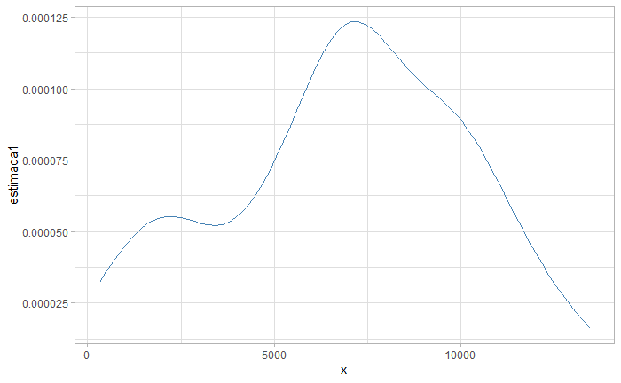

```r
ggplot(f_est)+
  geom_line(aes(x=x,y=estimada1),col="steelblue")+
  theme_light()
```